# Machine Learning : Linear Regression VS One Neuron

```
iteration  0 : (bias= 1 ,w1: 0.5 ) --->mse= 217.99  | update: dbias= -24.18 , dw1= -155.97
```

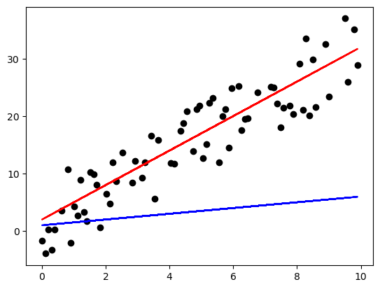

```
iteration  1 : (bias= 1.24 ,w1: 2.06 ) --->mse= 45.79  | update: dbias= -9.13 , dw1= -59.66
iteration  2 : (bias= 1.33 ,w1: 2.66 ) --->mse= 20.61  | update: dbias= -3.37 , dw1= -22.83
iteration  3 : (bias= 1.37 ,w1: 2.88 ) --->mse= 16.93  | update: dbias= -1.17 , dw1= -8.75
iteration  4 : (bias= 1.38 ,w1: 2.97 ) --->mse= 16.39  | update: dbias= -0.33 , dw1= -3.36
iteration  5 : (bias= 1.38 ,w1: 3.01 ) --->mse= 16.31  | update: dbias= -0.01 , dw1= -1.3
iteration  6 : (bias= 1.38 ,w1: 3.02 ) --->mse= 16.3  | update: dbias= 0.11 , dw1= -0.52
iteration  7 : (bias= 1.38 ,w1: 3.02 ) --->mse= 16.3  | update: dbias= 0.16 , dw1= -0.22
iteration  8 : (bias= 1.38 ,w1: 3.03 ) --->mse= 16.3  | update: dbias= 0.17 , dw1= -0.1
iteration  9 : (bias= 1.38 ,w1: 3.03 ) --->mse= 16.3  | update: dbias= 0.18 , dw1= -0.06
iteration  10 : (bias= 1.38 ,w1: 3.03 ) --->mse= 16.3  | update: dbias= 0.18 , dw1= -0.04
iteration  11 : (bias= 1.37 ,w1: 3.03 ) --->mse= 16.3  | update: dbias= 0.18 , dw1= -0.03
iteration  12 : (bias= 1.37 ,w1: 3.03 ) --->mse= 16.3  | update: dbias= 0.18 , dw1= -0.03
iteration  13 : (bias= 1.37 ,w1: 3.03 ) --->mse= 16.3  | update: dbias= 0.18 , dw1= -0.03
iteration  14 : (bias= 1.37 ,w1: 3.03 ) --->mse= 16.3  | update: dbias= 0.18 , dw1= -0.03
iteration  15 : (bias= 1.37 ,w1: 3.03 ) --->mse= 16.3  | update: dbias= 0.18 , dw1= -0.03
iteration  16 : (bias= 1.37 ,w1: 3.03 ) --->mse= 16.3  | update: dbias= 0.18 , dw1= -0.03
iteration  17 : (bias= 1.36 ,w1: 3.03 ) --->mse= 16.3  | update: dbias= 0.17 , dw1= -0.03
iteration  18 : (bias= 1.36 ,w1: 3.03 ) --->mse= 16.3  | update: dbias= 0.17 , dw1= -0.03
iteration  19 : (bias= 1.36 ,w1: 3.03 ) --->mse= 16.3  | update: dbias= 0.17 , dw1= -0.03
iteration  20 : (bias= 1.36 ,w1: 3.03 ) --->mse= 16.29  | update: dbias= 0.17 , dw1= -0.03
iteration  21 : (bias= 1.36 ,w1: 3.03 ) --->mse= 16.29  | update: dbias= 0.17 , dw1= -0.03
iteration  22 : (bias= 1.35 ,w1: 3.03 ) --->mse= 16.29  | update: dbias= 0.17 , dw1= -0.03
iteration  23 : (bias= 1.35 ,w1: 3.03 ) --->mse= 16.29  | update: dbias= 0.17 , dw1= -0.03
iteration  24 : (bias= 1.35 ,w1: 3.03 ) --->mse= 16.29  | update: dbias= 0.17 , dw1= -0.03
iteration  25 : (bias= 1.35 ,w1: 3.03 ) --->mse= 16.29  | update: dbias= 0.17 , dw1= -0.03
iteration  26 : (bias= 1.35 ,w1: 3.03 ) --->mse= 16.29  | update: dbias= 0.17 , dw1= -0.03
iteration  27 : (bias= 1.35 ,w1: 3.03 ) --->mse= 16.29  | update: dbias= 0.17 , dw1= -0.03
iteration  28 : (bias= 1.34 ,w1: 3.03 ) --->mse= 16.29  | update: dbias= 0.16 , dw1= -0.03
iteration  29 : (bias= 1.34 ,w1: 3.03 ) --->mse= 16.29  | update: dbias= 0.16 , dw1= -0.03
iteration  30 : (bias= 1.34 ,w1: 3.03 ) --->mse= 16.29  | update: dbias= 0.16 , dw1= -0.03
iteration  31 : (bias= 1.34 ,w1: 3.03 ) --->mse= 16.29  | update: dbias= 0.16 , dw1= -0.03
iteration  32 : (bias= 1.34 ,w1: 3.03 ) --->mse= 16.29  | update: dbias= 0.16 , dw1= -0.03
iteration  33 : (bias= 1.34 ,w1: 3.03 ) --->mse= 16.29  | update: dbias= 0.16 , dw1= -0.03
iteration  34 : (bias= 1.33 ,w1: 3.03 ) --->mse= 16.29  | update: dbias= 0.16 , dw1= -0.02
iteration  35 : (bias= 1.33 ,w1: 3.03 ) --->mse= 16.29  | update: dbias= 0.16 , dw1= -0.02
iteration  36 : (bias= 1.33 ,w1: 3.03 ) --->mse= 16.29  | update: dbias= 0.16 , dw1= -0.02
iteration  37 : (bias= 1.33 ,w1: 3.04 ) --->mse= 16.29  | update: dbias= 0.16 , dw1= -0.02
iteration  38 : (bias= 1.33 ,w1: 3.04 ) --->mse= 16.29  | update: dbias= 0.16 , dw1= -0.02
iteration  39 : (bias= 1.33 ,w1: 3.04 ) --->mse= 16.29  | update: dbias= 0.15 , dw1= -0.02
iteration  40 : (bias= 1.33 ,w1: 3.04 ) --->mse= 16.29  | update: dbias= 0.15 , dw1= -0.02
```

[output cut: 45 more lines]

```
iteration  86 : (bias= 1.26 ,w1: 3.05 ) --->mse= 16.28  | update: dbias= 0.12 , dw1= -0.02
iteration  87 : (bias= 1.26 ,w1: 3.05 ) --->mse= 16.28  | update: dbias= 0.12 , dw1= -0.02
iteration  88 : (bias= 1.26 ,w1: 3.05 ) --->mse= 16.28  | update: dbias= 0.12 , dw1= -0.02
iteration  89 : (bias= 1.26 ,w1: 3.05 ) --->mse= 16.28  | update: dbias= 0.12 , dw1= -0.02
iteration  90 : (bias= 1.26 ,w1: 3.05 ) --->mse= 16.28  | update: dbias= 0.12 , dw1= -0.02
iteration  91 : (bias= 1.26 ,w1: 3.05 ) --->mse= 16.28  | update: dbias= 0.12 , dw1= -0.02
iteration  92 : (bias= 1.26 ,w1: 3.05 ) --->mse= 16.28  | update: dbias= 0.12 , dw1= -0.02
iteration  93 : (bias= 1.25 ,w1: 3.05 ) --->mse= 16.28  | update: dbias= 0.12 , dw1= -0.02
iteration  94 : (bias= 1.25 ,w1: 3.05 ) --->mse= 16.28  | update: dbias= 0.12 , dw1= -0.02
iteration  95 : (bias= 1.25 ,w1: 3.05 ) --->mse= 16.28  | update: dbias= 0.11 , dw1= -0.02
iteration  96 : (bias= 1.25 ,w1: 3.05 ) --->mse= 16.28  | update: dbias= 0.11 , dw1= -0.02
iteration  97 : (bias= 1.25 ,w1: 3.05 ) --->mse= 16.28  | update: dbias= 0.11 , dw1= -0.02
iteration  98 : (bias= 1.25 ,w1: 3.05 ) --->mse= 16.28  | update: dbias= 0.11 , dw1= -0.02
iteration  99 : (bias= 1.25 ,w1: 3.05 ) --->mse= 16.28  | update: dbias= 0.11 , dw1= -0.02
iteration  100 : (bias= 1.25 ,w1: 3.05 ) --->mse= 16.28  | update: dbias= 0.11 , dw1= -0.02
```

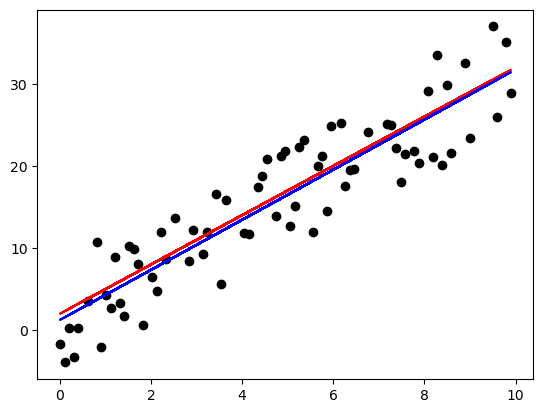

```
iteration  101 : (bias= 1.25 ,w1: 3.05 ) --->mse= 16.28  | update: dbias= 0.11 , dw1= -0.02
iteration  102 : (bias= 1.24 ,w1: 3.05 ) --->mse= 16.28  | update: dbias= 0.11 , dw1= -0.02
iteration  103 : (bias= 1.24 ,w1: 3.05 ) --->mse= 16.28  | update: dbias= 0.11 , dw1= -0.02
iteration  104 : (bias= 1.24 ,w1: 3.05 ) --->mse= 16.28  | update: dbias= 0.11 , dw1= -0.02
iteration  105 : (bias= 1.24 ,w1: 3.05 ) --->mse= 16.28  | update: dbias= 0.11 , dw1= -0.02
iteration  106 : (bias= 1.24 ,w1: 3.05 ) --->mse= 16.28  | update: dbias= 0.11 , dw1= -0.02
iteration  107 : (bias= 1.24 ,w1: 3.05 ) --->mse= 16.28  | update: dbias= 0.11 , dw1= -0.02
iteration  108 : (bias= 1.24 ,w1: 3.05 ) --->mse= 16.28  | update: dbias= 0.11 , dw1= -0.02
iteration  109 : (bias= 1.24 ,w1: 3.05 ) --->mse= 16.28  | update: dbias= 0.11 , dw1= -0.02
iteration  110 : (bias= 1.24 ,w1: 3.05 ) --->mse= 16.28  | update: dbias= 0.11 , dw1= -0.02
iteration  111 : (bias= 1.23 ,w1: 3.05 ) --->mse= 16.28  | update: dbias= 0.1 , dw1= -0.02
iteration  112 : (bias= 1.23 ,w1: 3.05 ) --->mse= 16.28  | update: dbias= 0.1 , dw1= -0.02
iteration  113 : (bias= 1.23 ,w1: 3.05 ) --->mse= 16.28  | update: dbias= 0.1 , dw1= -0.02
iteration  114 : (bias= 1.23 ,w1: 3.05 ) --->mse= 16.28  | update: dbias= 0.1 , dw1= -0.02
iteration  115 : (bias= 1.23 ,w1: 3.05 ) --->mse= 16.28  | update: dbias= 0.1 , dw1= -0.02
iteration  116 : (bias= 1.23 ,w1: 3.05 ) --->mse= 16.28  | update: dbias= 0.1 , dw1= -0.02
iteration  117 : (bias= 1.23 ,w1: 3.05 ) --->mse= 16.28  | update: dbias= 0.1 , dw1= -0.02
iteration  118 : (bias= 1.23 ,w1: 3.05 ) --->mse= 16.28  | update: dbias= 0.1 , dw1= -0.02
iteration  119 : (bias= 1.23 ,w1: 3.05 ) --->mse= 16.28  | update: dbias= 0.1 , dw1= -0.02
iteration  120 : (bias= 1.23 ,w1: 3.05 ) --->mse= 16.28  | update: dbias= 0.1 , dw1= -0.02
iteration  121 : (bias= 1.22 ,w1: 3.05 ) --->mse= 16.28  | update: dbias= 0.1 , dw1= -0.02
iteration  122 : (bias= 1.22 ,w1: 3.05 ) --->mse= 16.28  | update: dbias= 0.1 , dw1= -0.02
iteration  123 : (bias= 1.22 ,w1: 3.05 ) --->mse= 16.28  | update: dbias= 0.1 , dw1= -0.02
iteration  124 : (bias= 1.22 ,w1: 3.05 ) --->mse= 16.28  | update: dbias= 0.1 , dw1= -0.02
iteration  125 : (bias= 1.22 ,w1: 3.05 ) --->mse= 16.28  | update: dbias= 0.1 , dw1= -0.02
iteration  126 : (bias= 1.22 ,w1: 3.05 ) --->mse= 16.28  | update: dbias= 0.1 , dw1= -0.02
iteration  127 : (bias= 1.22 ,w1: 3.05 ) --->mse= 16.28  | update: dbias= 0.1 , dw1= -0.02
iteration  128 : (bias= 1.22 ,w1: 3.05 ) --->mse= 16.28  | update: dbias= 0.1 , dw1= -0.01
iteration  129 : (bias= 1.22 ,w1: 3.05 ) --->mse= 16.28  | update: dbias= 0.1 , dw1= -0.01
iteration  130 : (bias= 1.22 ,w1: 3.05 ) --->mse= 16.28  | update: dbias= 0.09 , dw1= -0.01
iteration  131 : (bias= 1.21 ,w1: 3.05 ) --->mse= 16.28  | update: dbias= 0.09 , dw1= -0.01
iteration  132 : (bias= 1.21 ,w1: 3.05 ) --->mse= 16.28  | update: dbias= 0.09 , dw1= -0.01
iteration  133 : (bias= 1.21 ,w1: 3.05 ) --->mse= 16.28  | update: dbias= 0.09 , dw1= -0.01
iteration  134 : (bias= 1.21 ,w1: 3.05 ) --->mse= 16.28  | update: dbias= 0.09 , dw1= -0.01
iteration  135 : (bias= 1.21 ,w1: 3.05 ) --->mse= 16.27  | update: dbias= 0.09 , dw1= -0.01
iteration  136 : (bias= 1.21 ,w1: 3.05 ) --->mse= 16.27  | update: dbias= 0.09 , dw1= -0.01
iteration  137 : (bias= 1.21 ,w1: 3.05 ) --->mse= 16.27  | update: dbias= 0.09 , dw1= -0.01
iteration  138 : (bias= 1.21 ,w1: 3.05 ) --->mse= 16.27  | update: dbias= 0.09 , dw1= -0.01
iteration  139 : (bias= 1.21 ,w1: 3.05 ) --->mse= 16.27  | update: dbias= 0.09 , dw1= -0.01
iteration  140 : (bias= 1.21 ,w1: 3.05 ) --->mse= 16.27  | update: dbias= 0.09 , dw1= -0.01
```

[output cut: 45 more lines]

```
iteration  186 : (bias= 1.17 ,w1: 3.06 ) --->mse= 16.27  | update: dbias= 0.07 , dw1= -0.01
iteration  187 : (bias= 1.17 ,w1: 3.06 ) --->mse= 16.27  | update: dbias= 0.07 , dw1= -0.01
iteration  188 : (bias= 1.17 ,w1: 3.06 ) --->mse= 16.27  | update: dbias= 0.07 , dw1= -0.01
iteration  189 : (bias= 1.17 ,w1: 3.06 ) --->mse= 16.27  | update: dbias= 0.07 , dw1= -0.01
iteration  190 : (bias= 1.17 ,w1: 3.06 ) --->mse= 16.27  | update: dbias= 0.07 , dw1= -0.01
iteration  191 : (bias= 1.17 ,w1: 3.06 ) --->mse= 16.27  | update: dbias= 0.07 , dw1= -0.01
iteration  192 : (bias= 1.17 ,w1: 3.06 ) --->mse= 16.27  | update: dbias= 0.07 , dw1= -0.01
iteration  193 : (bias= 1.16 ,w1: 3.06 ) --->mse= 16.27  | update: dbias= 0.07 , dw1= -0.01
iteration  194 : (bias= 1.16 ,w1: 3.06 ) --->mse= 16.27  | update: dbias= 0.07 , dw1= -0.01
iteration  195 : (bias= 1.16 ,w1: 3.06 ) --->mse= 16.27  | update: dbias= 0.07 , dw1= -0.01
iteration  196 : (bias= 1.16 ,w1: 3.06 ) --->mse= 16.27  | update: dbias= 0.07 , dw1= -0.01
iteration  197 : (bias= 1.16 ,w1: 3.06 ) --->mse= 16.27  | update: dbias= 0.07 , dw1= -0.01
iteration  198 : (bias= 1.16 ,w1: 3.06 ) --->mse= 16.27  | update: dbias= 0.07 , dw1= -0.01
iteration  199 : (bias= 1.16 ,w1: 3.06 ) --->mse= 16.27  | update: dbias= 0.07 , dw1= -0.01
iteration  200 : (bias= 1.16 ,w1: 3.06 ) --->mse= 16.27  | update: dbias= 0.06 , dw1= -0.01
```

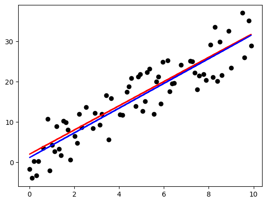

```
iteration  201 : (bias= 1.16 ,w1: 3.06 ) --->mse= 16.27  | update: dbias= 0.06 , dw1= -0.01
iteration  202 : (bias= 1.16 ,w1: 3.06 ) --->mse= 16.27  | update: dbias= 0.06 , dw1= -0.01
iteration  203 : (bias= 1.16 ,w1: 3.06 ) --->mse= 16.27  | update: dbias= 0.06 , dw1= -0.01
iteration  204 : (bias= 1.16 ,w1: 3.06 ) --->mse= 16.27  | update: dbias= 0.06 , dw1= -0.01
iteration  205 : (bias= 1.16 ,w1: 3.06 ) --->mse= 16.27  | update: dbias= 0.06 , dw1= -0.01
iteration  206 : (bias= 1.16 ,w1: 3.06 ) --->mse= 16.27  | update: dbias= 0.06 , dw1= -0.01
iteration  207 : (bias= 1.16 ,w1: 3.06 ) --->mse= 16.27  | update: dbias= 0.06 , dw1= -0.01
iteration  208 : (bias= 1.16 ,w1: 3.06 ) --->mse= 16.27  | update: dbias= 0.06 , dw1= -0.01
iteration  209 : (bias= 1.15 ,w1: 3.06 ) --->mse= 16.27  | update: dbias= 0.06 , dw1= -0.01
iteration  210 : (bias= 1.15 ,w1: 3.06 ) --->mse= 16.27  | update: dbias= 0.06 , dw1= -0.01
iteration  211 : (bias= 1.15 ,w1: 3.06 ) --->mse= 16.27  | update: dbias= 0.06 , dw1= -0.01
iteration  212 : (bias= 1.15 ,w1: 3.06 ) --->mse= 16.27  | update: dbias= 0.06 , dw1= -0.01
iteration  213 : (bias= 1.15 ,w1: 3.06 ) --->mse= 16.27  | update: dbias= 0.06 , dw1= -0.01
iteration  214 : (bias= 1.15 ,w1: 3.06 ) --->mse= 16.27  | update: dbias= 0.06 , dw1= -0.01
iteration  215 : (bias= 1.15 ,w1: 3.06 ) --->mse= 16.27  | update: dbias= 0.06 , dw1= -0.01
iteration  216 : (bias= 1.15 ,w1: 3.06 ) --->mse= 16.27  | update: dbias= 0.06 , dw1= -0.01
iteration  217 : (bias= 1.15 ,w1: 3.06 ) --->mse= 16.27  | update: dbias= 0.06 , dw1= -0.01
iteration  218 : (bias= 1.15 ,w1: 3.06 ) --->mse= 16.27  | update: dbias= 0.06 , dw1= -0.01
iteration  219 : (bias= 1.15 ,w1: 3.06 ) --->mse= 16.27  | update: dbias= 0.06 , dw1= -0.01
iteration  220 : (bias= 1.15 ,w1: 3.06 ) --->mse= 16.27  | update: dbias= 0.06 , dw1= -0.01
iteration  221 : (bias= 1.15 ,w1: 3.06 ) --->mse= 16.27  | update: dbias= 0.06 , dw1= -0.01
iteration  222 : (bias= 1.15 ,w1: 3.06 ) --->mse= 16.27  | update: dbias= 0.06 , dw1= -0.01
iteration  223 : (bias= 1.15 ,w1: 3.06 ) --->mse= 16.27  | update: dbias= 0.06 , dw1= -0.01
iteration  224 : (bias= 1.15 ,w1: 3.06 ) --->mse= 16.27  | update: dbias= 0.06 , dw1= -0.01
iteration  225 : (bias= 1.15 ,w1: 3.06 ) --->mse= 16.27  | update: dbias= 0.06 , dw1= -0.01
iteration  226 : (bias= 1.14 ,w1: 3.06 ) --->mse= 16.27  | update: dbias= 0.06 , dw1= -0.01
iteration  227 : (bias= 1.14 ,w1: 3.06 ) --->mse= 16.27  | update: dbias= 0.06 , dw1= -0.01
iteration  228 : (bias= 1.14 ,w1: 3.06 ) --->mse= 16.27  | update: dbias= 0.06 , dw1= -0.01
iteration  229 : (bias= 1.14 ,w1: 3.06 ) --->mse= 16.27  | update: dbias= 0.06 , dw1= -0.01
iteration  230 : (bias= 1.14 ,w1: 3.06 ) --->mse= 16.27  | update: dbias= 0.06 , dw1= -0.01
iteration  231 : (bias= 1.14 ,w1: 3.06 ) --->mse= 16.27  | update: dbias= 0.05 , dw1= -0.01
iteration  232 : (bias= 1.14 ,w1: 3.06 ) --->mse= 16.27  | update: dbias= 0.05 , dw1= -0.01
iteration  233 : (bias= 1.14 ,w1: 3.06 ) --->mse= 16.27  | update: dbias= 0.05 , dw1= -0.01
iteration  234 : (bias= 1.14 ,w1: 3.06 ) --->mse= 16.27  | update: dbias= 0.05 , dw1= -0.01
iteration  235 : (bias= 1.14 ,w1: 3.06 ) --->mse= 16.27  | update: dbias= 0.05 , dw1= -0.01
iteration  236 : (bias= 1.14 ,w1: 3.06 ) --->mse= 16.27  | update: dbias= 0.05 , dw1= -0.01
iteration  237 : (bias= 1.14 ,w1: 3.06 ) --->mse= 16.27  | update: dbias= 0.05 , dw1= -0.01
iteration  238 : (bias= 1.14 ,w1: 3.07 ) --->mse= 16.27  | update: dbias= 0.05 , dw1= -0.01
iteration  239 : (bias= 1.14 ,w1: 3.07 ) --->mse= 16.27  | update: dbias= 0.05 , dw1= -0.01
iteration  240 : (bias= 1.14 ,w1: 3.07 ) --->mse= 16.27  | update: dbias= 0.05 , dw1= -0.01
```

[output cut: 45 more lines]

```
iteration  286 : (bias= 1.12 ,w1: 3.07 ) --->mse= 16.27  | update: dbias= 0.04 , dw1= -0.01
iteration  287 : (bias= 1.12 ,w1: 3.07 ) --->mse= 16.27  | update: dbias= 0.04 , dw1= -0.01
iteration  288 : (bias= 1.11 ,w1: 3.07 ) --->mse= 16.27  | update: dbias= 0.04 , dw1= -0.01
iteration  289 : (bias= 1.11 ,w1: 3.07 ) --->mse= 16.27  | update: dbias= 0.04 , dw1= -0.01
iteration  290 : (bias= 1.11 ,w1: 3.07 ) --->mse= 16.27  | update: dbias= 0.04 , dw1= -0.01
iteration  291 : (bias= 1.11 ,w1: 3.07 ) --->mse= 16.27  | update: dbias= 0.04 , dw1= -0.01
iteration  292 : (bias= 1.11 ,w1: 3.07 ) --->mse= 16.27  | update: dbias= 0.04 , dw1= -0.01
iteration  293 : (bias= 1.11 ,w1: 3.07 ) --->mse= 16.27  | update: dbias= 0.04 , dw1= -0.01
iteration  294 : (bias= 1.11 ,w1: 3.07 ) --->mse= 16.27  | update: dbias= 0.04 , dw1= -0.01
iteration  295 : (bias= 1.11 ,w1: 3.07 ) --->mse= 16.27  | update: dbias= 0.04 , dw1= -0.01
iteration  296 : (bias= 1.11 ,w1: 3.07 ) --->mse= 16.27  | update: dbias= 0.04 , dw1= -0.01
iteration  297 : (bias= 1.11 ,w1: 3.07 ) --->mse= 16.27  | update: dbias= 0.04 , dw1= -0.01
iteration  298 : (bias= 1.11 ,w1: 3.07 ) --->mse= 16.27  | update: dbias= 0.04 , dw1= -0.01
iteration  299 : (bias= 1.11 ,w1: 3.07 ) --->mse= 16.27  | update: dbias= 0.04 , dw1= -0.01
iteration  300 : (bias= 1.11 ,w1: 3.07 ) --->mse= 16.27  | update: dbias= 0.04 , dw1= -0.01
```

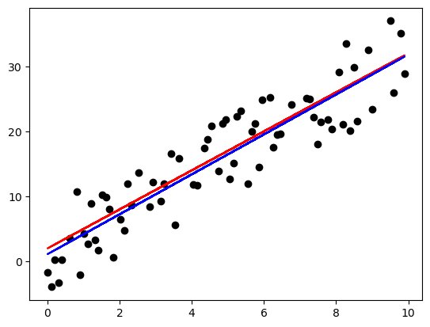

```
iteration  301 : (bias= 1.11 ,w1: 3.07 ) --->mse= 16.27  | update: dbias= 0.04 , dw1= -0.01
iteration  302 : (bias= 1.11 ,w1: 3.07 ) --->mse= 16.27  | update: dbias= 0.04 , dw1= -0.01
iteration  303 : (bias= 1.11 ,w1: 3.07 ) --->mse= 16.27  | update: dbias= 0.04 , dw1= -0.01
iteration  304 : (bias= 1.11 ,w1: 3.07 ) --->mse= 16.27  | update: dbias= 0.04 , dw1= -0.01
iteration  305 : (bias= 1.11 ,w1: 3.07 ) --->mse= 16.27  | update: dbias= 0.04 , dw1= -0.01
iteration  306 : (bias= 1.11 ,w1: 3.07 ) --->mse= 16.27  | update: dbias= 0.04 , dw1= -0.01
iteration  307 : (bias= 1.11 ,w1: 3.07 ) --->mse= 16.27  | update: dbias= 0.04 , dw1= -0.01
iteration  308 : (bias= 1.11 ,w1: 3.07 ) --->mse= 16.27  | update: dbias= 0.04 , dw1= -0.01
iteration  309 : (bias= 1.11 ,w1: 3.07 ) --->mse= 16.27  | update: dbias= 0.04 , dw1= -0.01
iteration  310 : (bias= 1.11 ,w1: 3.07 ) --->mse= 16.27  | update: dbias= 0.04 , dw1= -0.01
iteration  311 : (bias= 1.11 ,w1: 3.07 ) --->mse= 16.27  | update: dbias= 0.04 , dw1= -0.01
iteration  312 : (bias= 1.11 ,w1: 3.07 ) --->mse= 16.27  | update: dbias= 0.04 , dw1= -0.01
iteration  313 : (bias= 1.11 ,w1: 3.07 ) --->mse= 16.27  | update: dbias= 0.04 , dw1= -0.01
iteration  314 : (bias= 1.1 ,w1: 3.07 ) --->mse= 16.27  | update: dbias= 0.03 , dw1= -0.01
iteration  315 : (bias= 1.1 ,w1: 3.07 ) --->mse= 16.27  | update: dbias= 0.03 , dw1= -0.01
iteration  316 : (bias= 1.1 ,w1: 3.07 ) --->mse= 16.27  | update: dbias= 0.03 , dw1= -0.01
iteration  317 : (bias= 1.1 ,w1: 3.07 ) --->mse= 16.27  | update: dbias= 0.03 , dw1= -0.01
iteration  318 : (bias= 1.1 ,w1: 3.07 ) --->mse= 16.27  | update: dbias= 0.03 , dw1= -0.01
iteration  319 : (bias= 1.1 ,w1: 3.07 ) --->mse= 16.27  | update: dbias= 0.03 , dw1= -0.01
iteration  320 : (bias= 1.1 ,w1: 3.07 ) --->mse= 16.27  | update: dbias= 0.03 , dw1= -0.01
iteration  321 : (bias= 1.1 ,w1: 3.07 ) --->mse= 16.27  | update: dbias= 0.03 , dw1= -0.01
iteration  322 : (bias= 1.1 ,w1: 3.07 ) --->mse= 16.27  | update: dbias= 0.03 , dw1= -0.01
iteration  323 : (bias= 1.1 ,w1: 3.07 ) --->mse= 16.27  | update: dbias= 0.03 , dw1= -0.01
iteration  324 : (bias= 1.1 ,w1: 3.07 ) --->mse= 16.27  | update: dbias= 0.03 , dw1= -0.01
iteration  325 : (bias= 1.1 ,w1: 3.07 ) --->mse= 16.27  | update: dbias= 0.03 , dw1= -0.01
iteration  326 : (bias= 1.1 ,w1: 3.07 ) --->mse= 16.27  | update: dbias= 0.03 , dw1= -0.01
iteration  327 : (bias= 1.1 ,w1: 3.07 ) --->mse= 16.27  | update: dbias= 0.03 , dw1= -0.01
iteration  328 : (bias= 1.1 ,w1: 3.07 ) --->mse= 16.27  | update: dbias= 0.03 , dw1= -0.01
iteration  329 : (bias= 1.1 ,w1: 3.07 ) --->mse= 16.27  | update: dbias= 0.03 , dw1= -0.01
iteration  330 : (bias= 1.1 ,w1: 3.07 ) --->mse= 16.27  | update: dbias= 0.03 , dw1= -0.01
iteration  331 : (bias= 1.1 ,w1: 3.07 ) --->mse= 16.27  | update: dbias= 0.03 , dw1= -0.0
iteration  332 : (bias= 1.1 ,w1: 3.07 ) --->mse= 16.27  | update: dbias= 0.03 , dw1= -0.0
iteration  333 : (bias= 1.1 ,w1: 3.07 ) --->mse= 16.27  | update: dbias= 0.03 , dw1= -0.0
iteration  334 : (bias= 1.1 ,w1: 3.07 ) --->mse= 16.27  | update: dbias= 0.03 , dw1= -0.0
iteration  335 : (bias= 1.1 ,w1: 3.07 ) --->mse= 16.27  | update: dbias= 0.03 , dw1= -0.0
iteration  336 : (bias= 1.1 ,w1: 3.07 ) --->mse= 16.27  | update: dbias= 0.03 , dw1= -0.0
iteration  337 : (bias= 1.1 ,w1: 3.07 ) --->mse= 16.27  | update: dbias= 0.03 , dw1= -0.0
iteration  338 : (bias= 1.1 ,w1: 3.07 ) --->mse= 16.27  | update: dbias= 0.03 , dw1= -0.0
iteration  339 : (bias= 1.1 ,w1: 3.07 ) --->mse= 16.27  | update: dbias= 0.03 , dw1= -0.0
iteration  340 : (bias= 1.1 ,w1: 3.07 ) --->mse= 16.27  | update: dbias= 0.03 , dw1= -0.0
```

[output cut: 45 more lines]

```
iteration  386 : (bias= 1.08 ,w1: 3.07 ) --->mse= 16.27  | update: dbias= 0.02 , dw1= -0.0
iteration  387 : (bias= 1.08 ,w1: 3.07 ) --->mse= 16.27  | update: dbias= 0.02 , dw1= -0.0
iteration  388 : (bias= 1.08 ,w1: 3.07 ) --->mse= 16.27  | update: dbias= 0.02 , dw1= -0.0
iteration  389 : (bias= 1.08 ,w1: 3.07 ) --->mse= 16.27  | update: dbias= 0.02 , dw1= -0.0
iteration  390 : (bias= 1.08 ,w1: 3.07 ) --->mse= 16.27  | update: dbias= 0.02 , dw1= -0.0
iteration  391 : (bias= 1.08 ,w1: 3.07 ) --->mse= 16.27  | update: dbias= 0.02 , dw1= -0.0
iteration  392 : (bias= 1.08 ,w1: 3.07 ) --->mse= 16.27  | update: dbias= 0.02 , dw1= -0.0
iteration  393 : (bias= 1.08 ,w1: 3.07 ) --->mse= 16.27  | update: dbias= 0.02 , dw1= -0.0
iteration  394 : (bias= 1.08 ,w1: 3.07 ) --->mse= 16.27  | update: dbias= 0.02 , dw1= -0.0
iteration  395 : (bias= 1.08 ,w1: 3.07 ) --->mse= 16.27  | update: dbias= 0.02 , dw1= -0.0
iteration  396 : (bias= 1.08 ,w1: 3.07 ) --->mse= 16.27  | update: dbias= 0.02 , dw1= -0.0
iteration  397 : (bias= 1.08 ,w1: 3.07 ) --->mse= 16.27  | update: dbias= 0.02 , dw1= -0.0
iteration  398 : (bias= 1.08 ,w1: 3.07 ) --->mse= 16.27  | update: dbias= 0.02 , dw1= -0.0
iteration  399 : (bias= 1.08 ,w1: 3.07 ) --->mse= 16.27  | update: dbias= 0.02 , dw1= -0.0
iteration  400 : (bias= 1.08 ,w1: 3.07 ) --->mse= 16.27  | update: dbias= 0.02 , dw1= -0.0
```

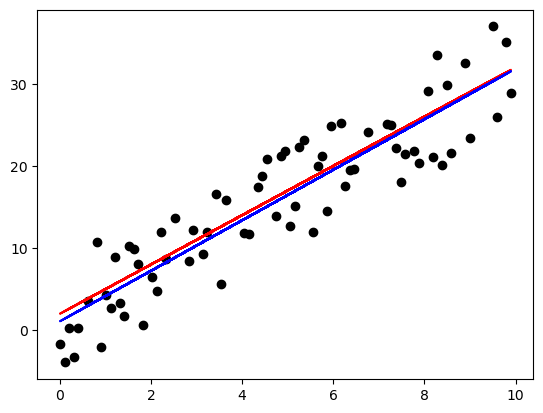

```
iteration  401 : (bias= 1.08 ,w1: 3.07 ) --->mse= 16.27  | update: dbias= 0.02 , dw1= -0.0
iteration  402 : (bias= 1.08 ,w1: 3.07 ) --->mse= 16.27  | update: dbias= 0.02 , dw1= -0.0
iteration  403 : (bias= 1.08 ,w1: 3.07 ) --->mse= 16.27  | update: dbias= 0.02 , dw1= -0.0
iteration  404 : (bias= 1.08 ,w1: 3.07 ) --->mse= 16.27  | update: dbias= 0.02 , dw1= -0.0
iteration  405 : (bias= 1.08 ,w1: 3.07 ) --->mse= 16.27  | update: dbias= 0.02 , dw1= -0.0
iteration  406 : (bias= 1.08 ,w1: 3.07 ) --->mse= 16.27  | update: dbias= 0.02 , dw1= -0.0
iteration  407 : (bias= 1.08 ,w1: 3.07 ) --->mse= 16.27  | update: dbias= 0.02 , dw1= -0.0
iteration  408 : (bias= 1.08 ,w1: 3.07 ) --->mse= 16.27  | update: dbias= 0.02 , dw1= -0.0
iteration  409 : (bias= 1.08 ,w1: 3.07 ) --->mse= 16.27  | update: dbias= 0.02 , dw1= -0.0
iteration  410 : (bias= 1.08 ,w1: 3.07 ) --->mse= 16.27  | update: dbias= 0.02 , dw1= -0.0
iteration  411 : (bias= 1.08 ,w1: 3.07 ) --->mse= 16.27  | update: dbias= 0.02 , dw1= -0.0
iteration  412 : (bias= 1.08 ,w1: 3.07 ) --->mse= 16.27  | update: dbias= 0.02 , dw1= -0.0
iteration  413 : (bias= 1.08 ,w1: 3.07 ) --->mse= 16.27  | update: dbias= 0.02 , dw1= -0.0
iteration  414 : (bias= 1.08 ,w1: 3.07 ) --->mse= 16.27  | update: dbias= 0.02 , dw1= -0.0
iteration  415 : (bias= 1.08 ,w1: 3.07 ) --->mse= 16.27  | update: dbias= 0.02 , dw1= -0.0
iteration  416 : (bias= 1.08 ,w1: 3.07 ) --->mse= 16.27  | update: dbias= 0.02 , dw1= -0.0
iteration  417 : (bias= 1.08 ,w1: 3.07 ) --->mse= 16.27  | update: dbias= 0.02 , dw1= -0.0
iteration  418 : (bias= 1.08 ,w1: 3.07 ) --->mse= 16.27  | update: dbias= 0.02 , dw1= -0.0
iteration  419 : (bias= 1.08 ,w1: 3.07 ) --->mse= 16.27  | update: dbias= 0.02 , dw1= -0.0
iteration  420 : (bias= 1.08 ,w1: 3.07 ) --->mse= 16.27  | update: dbias= 0.02 , dw1= -0.0
iteration  421 : (bias= 1.08 ,w1: 3.07 ) --->mse= 16.27  | update: dbias= 0.02 , dw1= -0.0
iteration  422 : (bias= 1.08 ,w1: 3.07 ) --->mse= 16.27  | update: dbias= 0.02 , dw1= -0.0
iteration  423 : (bias= 1.08 ,w1: 3.07 ) --->mse= 16.27  | update: dbias= 0.02 , dw1= -0.0
iteration  424 : (bias= 1.08 ,w1: 3.07 ) --->mse= 16.27  | update: dbias= 0.02 , dw1= -0.0
iteration  425 : (bias= 1.08 ,w1: 3.07 ) --->mse= 16.27  | update: dbias= 0.02 , dw1= -0.0
iteration  426 : (bias= 1.08 ,w1: 3.07 ) --->mse= 16.27  | update: dbias= 0.02 , dw1= -0.0
iteration  427 : (bias= 1.08 ,w1: 3.07 ) --->mse= 16.27  | update: dbias= 0.02 , dw1= -0.0
iteration  428 : (bias= 1.08 ,w1: 3.07 ) --->mse= 16.27  | update: dbias= 0.02 , dw1= -0.0
iteration  429 : (bias= 1.08 ,w1: 3.07 ) --->mse= 16.27  | update: dbias= 0.02 , dw1= -0.0
iteration  430 : (bias= 1.07 ,w1: 3.07 ) --->mse= 16.27  | update: dbias= 0.02 , dw1= -0.0
iteration  431 : (bias= 1.07 ,w1: 3.07 ) --->mse= 16.27  | update: dbias= 0.02 , dw1= -0.0
iteration  432 : (bias= 1.07 ,w1: 3.07 ) --->mse= 16.27  | update: dbias= 0.02 , dw1= -0.0
iteration  433 : (bias= 1.07 ,w1: 3.08 ) --->mse= 16.27  | update: dbias= 0.02 , dw1= -0.0
iteration  434 : (bias= 1.07 ,w1: 3.08 ) --->mse= 16.27  | update: dbias= 0.02 , dw1= -0.0
iteration  435 : (bias= 1.07 ,w1: 3.08 ) --->mse= 16.27  | update: dbias= 0.02 , dw1= -0.0
iteration  436 : (bias= 1.07 ,w1: 3.08 ) --->mse= 16.27  | update: dbias= 0.02 , dw1= -0.0
iteration  437 : (bias= 1.07 ,w1: 3.08 ) --->mse= 16.27  | update: dbias= 0.02 , dw1= -0.0
iteration  438 : (bias= 1.07 ,w1: 3.08 ) --->mse= 16.27  | update: dbias= 0.02 , dw1= -0.0
iteration  439 : (bias= 1.07 ,w1: 3.08 ) --->mse= 16.27  | update: dbias= 0.02 , dw1= -0.0
iteration  440 : (bias= 1.07 ,w1: 3.08 ) --->mse= 16.27  | update: dbias= 0.02 , dw1= -0.0
```

[output cut: 44 more lines]

```
iteration  485 : (bias= 1.07 ,w1: 3.08 ) --->mse= 16.27  | update: dbias= 0.01 , dw1= -0.0
iteration  486 : (bias= 1.07 ,w1: 3.08 ) --->mse= 16.27  | update: dbias= 0.01 , dw1= -0.0
iteration  487 : (bias= 1.07 ,w1: 3.08 ) --->mse= 16.27  | update: dbias= 0.01 , dw1= -0.0
iteration  488 : (bias= 1.07 ,w1: 3.08 ) --->mse= 16.27  | update: dbias= 0.01 , dw1= -0.0
iteration  489 : (bias= 1.07 ,w1: 3.08 ) --->mse= 16.27  | update: dbias= 0.01 , dw1= -0.0
iteration  490 : (bias= 1.07 ,w1: 3.08 ) --->mse= 16.27  | update: dbias= 0.01 , dw1= -0.0
iteration  491 : (bias= 1.07 ,w1: 3.08 ) --->mse= 16.27  | update: dbias= 0.01 , dw1= -0.0
iteration  492 : (bias= 1.07 ,w1: 3.08 ) --->mse= 16.27  | update: dbias= 0.01 , dw1= -0.0
iteration  493 : (bias= 1.06 ,w1: 3.08 ) --->mse= 16.27  | update: dbias= 0.01 , dw1= -0.0
iteration  494 : (bias= 1.06 ,w1: 3.08 ) --->mse= 16.27  | update: dbias= 0.01 , dw1= -0.0
iteration  495 : (bias= 1.06 ,w1: 3.08 ) --->mse= 16.27  | update: dbias= 0.01 , dw1= -0.0
iteration  496 : (bias= 1.06 ,w1: 3.08 ) --->mse= 16.27  | update: dbias= 0.01 , dw1= -0.0
iteration  497 : (bias= 1.06 ,w1: 3.08 ) --->mse= 16.27  | update: dbias= 0.01 , dw1= -0.0
iteration  498 : (bias= 1.06 ,w1: 3.08 ) --->mse= 16.27  | update: dbias= 0.01 , dw1= -0.0
iteration  499 : (bias= 1.06 ,w1: 3.08 ) --->mse= 16.27  | update: dbias= 0.01 , dw1= -0.0
```

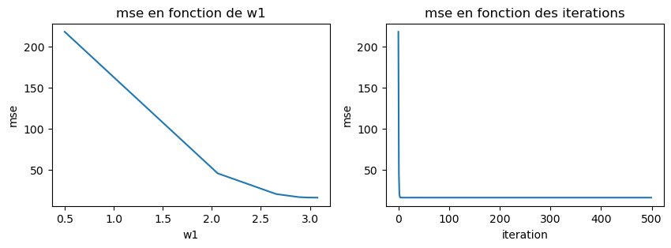

```python
def trainNN1(X,y):
    #hyperparameters initialisation: tuning parameters
    learning_rate=0.001
    epochs=500
    #model parameters initialisation
    w1=0.5 #
    bias=1
    #----------------------
    n=len(X) #data size
    global mseList
    global w1List
    mseList=[]
    w1List=[]


    #training
    for i in range(epochs):
        ws=bias+w1*X #prediction
        yhat=activation(ws)

        error=y-yhat # Error
        squared_error=error**2 #squared error
        mse=(1/n)*sum(squared_error) #mean squared error
        #print("(",bias, ",", w1, ") ----->",mse)
        mseList.append(mse)
        w1List.append(w1)


        dw1=(-2/n)*np.sum(X*(y-yhat)) # partial derivate of mse / w1
        dbias=(-2/n)*np.sum((y-yhat)) #partial derivate of mse / w1
        print("iteration ",i,": (bias=",round(bias,2),",w1:",round(w1,2),") --->mse=",round(mse,2)," | update: dbias=",round(dbias,2),", dw1=",round(dw1,2))
        if i%100==0:
            ploter(X,y,bias,w1)


        w1=w1-dw1*learning_rate # orientation (-) + pas d'apprentissage (l)
        bias=bias-dbias*learning_rate

    return bias,w1


#exécution
bias,w1=train3(X_train,y_train)
tracer_graphes(w1List,mseList,[i for i in range(500)])
```

## I.3. Linear Regression Model: Many Feature feature (Advertissing problem)

Objectif est de prévoir les ventes (sales) à realiser suite à un investissement en publicité  
la publicité peut se faire en TV, RADIO, NewsPaper question: quelle est la meilleur combinaison à utiliser pour faire un bon Sales. exemple: si on souhaite investir 10000 Euro (TV=?, Radio? NewsPaper? afinde maximiser Sales)

trouver le modele: Sales(TV,Radio, Neawspaper)=bias+w1*TV+w2*radio+w3*newsPaper

#### Step 1: Load / Initialize Data

```python
import pandas as pnd #dataframe
data_frame=pnd.read_csv("advertising.csv")
data_frame.head()
#les trois premières colonnes: features
#la dernière colonne target
```

|  | TV | Radio | Newspaper | Sales |
| --- | --- | --- | --- | --- |
| 0 | 230.1 | 37.8 | 69.2 | 22.1 |
| 1 | 44.5 | 39.3 | 45.1 | 10.4 |
| 2 | 17.2 | 45.9 | 69.3 | 12.0 |
| 3 | 151.5 | 41.3 | 58.5 | 16.5 |
| 4 | 180.8 | 10.8 | 58.4 | 17.9 |

```python
#convertir le dataframe en array
data=np.array(data_frame)
#extraire la partie features
X=np.array([data[i,:3] for i in range(len(data))])
#extraire la partie target
y=np.array([data[i,3] for i in range(len(data))])
```

#### Step 2: Data Analysis - Data Preparaton

Avant de commencer l'entrainement du modèle, il est nécessaire d'appliquer la mise à l'échelle (scaling) sur les données pour que notre algorithme d'apprentissage converge.  
Si non, et à cause de la formule: dw1=(-2/n)*np.sum(X*(y-yhat)) (voir train3) on risque d'avoir de tres grandes valeurs, ce qui peut permettre de dépasser l'optimum et qui entraine des valeurs exponentielles de mse.

pour la mise à l'échelle, on peut utiliser les techniques suivantes:

#### -Normalisation

la nomralisation se fait à l'aide de la formule suivante:

[figure not shown]

on peut utiliser le code suivant:

X_norm = (X - X.min(axis=0))/ (X.max(axis=0)-X.min(axis=0))

Aussi, on peut utiliser MinMaxScaler de la librairie sklearn.preprocessing

#### -Standardisation

la standardisation se fait suite à la formule suivante:

[figure not shown]

on peut utiliser le code suivant:

mu=X.mean()  
sigma=X.std()  
X_stand = (X - mu)/ sigma

Aussi, on peut utiliser StandardScaler de la librairie sklearn.preprocessing

différence entre normalisation et standardisation

[figure not shown]

dans notre cas, nous allons utiliser StadardScaller vu que les données suivent une distribution gaussienne

[figure not shown]

```python
#
from sklearn.preprocessing import StandardScaler
scaler= StandardScaler()
X = scaler.fit_transform(X)
```

#### Step 3: Split Data

```python
X_train, X_test, y_train, y_test = train_test_split(X, y, test_size=0.3, random_state=44) #
#random_state=valeur, permet de générer le même dataset à chaque fois. cette valeur assure d'avoir le même random
```

### I.1.2. Model (using gradient descent)

#### Step 1: Model Trainig

```python
def train4(x1,x2,x3,y):
    #hyperparameters initialisation: tuning parameters
    learning_rate=0.01
    epochs=10000
    #model parameters initialisation
    w1=0.5 #
    w2=0.5
    w3=0.5
    bias=0.5
    #recherche.....
    #----------------------
    n=len(y) #data size


    #training
    for i in range(epochs):
        yhat=bias+w1*x1+w2*x2+w3*x3 #prediction

        dw1=(-2/n)*np.sum(x1*(y-yhat)) # partial derivate of mse / w1
        dw2=(-2/n)*np.sum(x2*(y-yhat)) # partial derivate of mse / w1
        dw3=(-2/n)*np.sum(x3*(y-yhat)) # partial derivate of mse / w1

        dbias=(-2/n)*np.sum((y-yhat)) #partial derivate of mse / bias

        w1=w1-dw1*learning_rate  #update w1
        w2=w2-dw2*learning_rate  #update w2
        w3=w3-dw3*learning_rate  #update w3

        bias=bias-dbias*learning_rate #update bias

    return bias,w1,w2,w3
```

```python
#data training
x1,x2,x3=X_train[:,0],X_train[:,1],X_train[:,2]
#traning
bias,w1,w2,w3=train4(x1,x2,x3,y_train)
```

#### Step 2: Model Prediction

```python
def predict(x1,x2,x3):
    return bias+w1*x1+w2*x2+w3*x3
```

```python
#data test
x1,x2,x3=X_test[:,0],X_test[:,1],X_test[:,2]
#prediction
yhat=predict(x1,x2,x3)
```

#### Step 3: Model Evaluation

calculer MSE du modèle trouvé

```python
mseModel1=mse(y_test,yhat)
print(mseModel1)
```

```
2.1004629949424114
```

**comparer le modèle trouvé (bias,[w1,w2,w3]) avec celui trouvé à l'aide de sklearn**

```python
# LinearRegression de sklearn
from sklearn.linear_model import LinearRegression
```

```python
#les phases à suivre:
#--1.créer le modèle à l'aide de LinearRegression()
#--2.entrainer le modèle à l'aide de fit()
#--2.faire les prédictions à l'aide de predict()


model=LinearRegression()
model.fit(X_train,y_train)
y_hat2=model.predict(X_test)
mseModel2=mse(y_test,y_hat2)
print(model.intercept_,model.coef_)
```

```
15.180754089219374 [ 4.73890423  1.59857798 -0.05919934]
```

```python
print(mseModel2)
```

```
2.1004629949423856
```

## I.4. One Neurone Model: Many Feature feature (Advertissing problem)

[figure not shown]

```python
def activation(z):
    return z
```

```python
#model: h(x1,x2,x3)=bias+w1.x1+w2.x2+w3.x3
#model (bias,w1,w2,w3)
#init: bias=, w1=,w2=,w3=

#update
#w1=w1-dw1
#w2=w2-dw2
#w3=w3-dw3
#bias=bias-dbias

def train5(x1,x2,x3,y):
    #hyperparameters initialisation: tuning parameters
    learning_rate=0.01
    epochs=1000
    #model parameters initialisation
    w1=0.5 #
    w2=0.5
    w3=0.5
    bias=0.5
    #----------------------
    n=len(y) #data size


    #training
    for i in range(epochs):
        ws=bias+w1*x1+w2*x2+w3*x3 #prediction
        yhat=activation(ws)

        dw1=(-2/n)*np.sum(x1*(y-yhat)) # partial derivate of mse / w1
        dw2=(-2/n)*np.sum(x2*(y-yhat)) # partial derivate of mse / w1
        dw3=(-2/n)*np.sum(x3*(y-yhat)) # partial derivate of mse / w1

        dbias=(-2/n)*np.sum((y-yhat)) #partial derivate of mse / w1

        w1=w1-dw1*learning_rate # orientation (-) + pas d'apprentissage (l)
        w2=w2-dw2*learning_rate # orientation (-) + pas d'apprentissage (l)
        w3=w3-dw3*learning_rate # orientation (-) + pas d'apprentissage (l)

        bias=bias-dbias*learning_rate

    return bias,w1,w2,w3
```

```python
#data training
x1,x2,x3=X_train[:,0],X_train[:,1],X_train[:,2]
#traning
bias,w1,w2,w3=train5(x1,x2,x3,y_train)
```

```python
#predict
#mse
```

```python
def predict(x1,x2,x3):
    return bias+w1*x1+w2*x2+w3*x3
```

```python
#data test
x1,x2,x3=X_test[:,0],X_test[:,1],X_test[:,2]
#prediction
yhat=predict(x1,x2,x3)
```

```python
mseModelOneNeurone=mse(y_test,yhat)
print(mseModelOneNeurone)
```

```
2.1004629668280246
```

### Conclusion 2

**dans la partie précédente et pour un dataset simple, nous avons vu de près les éléments suivants:**  
1- ce que c'est un modèle de régression basé sur un seul neuron  
2- ce que c'est un neuron  
3- Adapter le gradient descent pour un neuron